# January 2020 Monthly Report

Author: Linh Do

Date Created: 2025-02-04

```r
set.seed(42)
```

```r
# Function to round numeric values to a specified number of decimal places
round.numerics <- function(x, digits){
  if(is.numeric(x)){
    x <- round(x = x, digits = digits)
  }
  return(x)
}

# Function to check, count and remove duplicates
handle_duplicates <- function(data) {
  dup_count <- sum(duplicated(data))
  dup_rows <- data[duplicated(data) | duplicated(data, fromLast = TRUE)]
  cleaned_data <- data[!duplicated(data), ]

  return(duplicates_count = dup_count)
}

#Function to check missing data
mean_missing <- function(x) {
  return(mean(is.na(x)))
}

# Function to count and calculate percentage
count_and_percentage <- function(dat, by_names, na.rm = TRUE){
  require(data.table)
  setDT(dat)
  total_count <- nrow(dat)
  tab <- dat[, .(Count = .N,
                 Percentage = 100 * (.N/total_count)), by = by_names]
  return(tab)
}
```

```r
#Extract data from the 'params' list in automation script created for this report. The data type = data table

customers_data = params$customers_data
products_data = params$products_data
trans_data = params$trans_data
views_data = params$views_data
```

```r
## Explore customers data
# Preview first few rows of customers_data
head(customers_data)
# Customer overview by gender and region
customers_data[, .N, keyby = c("gender", "region")]
# Count the number of unique customers
uniqueN(customers_data$customer_id)

## Explore products data
# Preview first few rows of products_data
head(products_data)
# Get unique product categories
unique(products_data$category)
# Summary statistics for product prices
summary(products_data$price)

## Explore transactions data
# Preview first few rows of transactions data
head(trans_data)
# Transactions data overview
trans_data_overview <- trans_data[, .(`Total Transactions` = .N,
                                      `Number of unique customers` =length(unique(customer_id)),
                                      `Number of unique products purchased`= uniqueN(trans_data$product_id),
                                      `Number of days has transactions` = uniqueN(as.Date(time)),
                                      `Total Revenue` = sum(price))]
trans_data_overview
# Check unique days in transactions data
unique(as.Date(views_data$time))
# Summary statistics for transaction prices
summary(trans_data$price)
# Get unique quantities purchased in  transactions data
unique(trans_data$quantity)
# Calculate the percentage of each quantity type in  transactions data
count_and_percentage(dat = trans_data,
                       by_names = "quantity")

## Explore views data
# Preview first few rows of views data
head(views_data)
# Views data overview
views_data_overview <- views_data[, .(`Total Views` = .N,
                                      `Number of unique customers` =length(unique(customer_id)),
                                      `Number of unique products viewed`= uniqueN(trans_data$product_id),
                                      `Number of days has views` = uniqueN(as.Date(time)))]
views_data_overview
# Check unique days in views data
unique(as.Date(views_data$time))
```

```r
#Check and remove duplicates
handle_duplicates(customers_data)
handle_duplicates(products_data)
handle_duplicates(trans_data)
handle_duplicates(views_data)

#Check missing data
customers_data[, lapply(X = .SD, FUN = "mean_missing")]
products_data[, lapply(X = .SD, FUN = "mean_missing")]
trans_data[, lapply(X = .SD, FUN = "mean_missing")]
views_data[, lapply(X = .SD, FUN = "mean_missing")]
```

```r
# Add variable 'revenue'
trans_data[, revenue := (price*quantity)]

# Calculate the total revenue of the whole month
total_revenue <- sum(trans_data$revenue)

# Retrieve the 'product_id' values from 'products_data' where the product category is "coat"
coat_prod_id = products_data[category == "coat"]$product_id
```

This report was prepared based on data from a specific month in response to the questions posed previously.

# 1 About Views

## 1.1 The 10 most viewed products during the first 7 days of the month.

```r
# Join views_data with products_data to add the category information
views_data <- views_data[products_data,
                          on = "product_id",
                          category := i.category]

# Count views for products viewed for first 7 days of the month
datatable(views_data[day(ymd_hms(time)) <8,
           .(view_count = .N),
           by = .(product_id, category)][order(-view_count)][1:10])
```

|  | product_id | category | view_count |
| --- | --- | --- | --- |
| 1 | hZmcs0gqq3PNAWCx | shoes | 237 |
| 2 | dMtPVNCmlSXcL6iP | shirt | 232 |
| 3 | OmXDXPBgWZByPuL9 | shoes | 223 |
| 4 | knT3UmtTLIeFYxZz | shirt | 221 |
| 5 | 7gvSWZqRcGq8ZNSB | pants | 213 |
| 6 | 74jHrAW0ZT5MS4LI | shirt | 210 |
| 7 | nrrrQlBJoFG8Tnwc | shoes | 208 |
| 8 | VKXVJeE4fSQOB8JL | shirt | 207 |
| 9 | HwSMLy72SvkjtS4r | shirt | 207 |
| 10 | Nkt3V7TBwUwCj0KH | shirt | 206 |

## 1.2 The 10 most viewed products for each category during the whole month.

```r
# Create a new table 'product_viewed' that counts the number of views for each product and its category

product_viewed <- views_data[, .(view_count = .N), by = c("product_id", "category")]
```

### 1.2.1 Shirt

```r
# Filter the 'product_viewed' data table to include only rows where the category is "shirt"

datatable(product_viewed[category == "shirt"][order(-view_count)][1:10, .(product_id, view_count)])
```

|  | product_id | view_count |
| --- | --- | --- |
| 1 | bBulnXVLIdig115C | 738 |
| 2 | sUyucfA4dOk5ISzi | 707 |
| 3 | CdhnKXsxeAsh4NnV | 706 |
| 4 | knT3UmtTLIeFYxZz | 701 |
| 5 | DAoAWJ5D7eMTgpf9 | 699 |
| 6 | jkTUEt7au7Q9Qzx0 | 699 |
| 7 | ARFO7fcchrl6f9KJ | 697 |
| 8 | Ecw6h0ih2HwU5BtA | 697 |
| 9 | VKXVJeE4fSQOB8JL | 690 |
| 10 | UCze0r84VIDYinFN | 690 |

### 1.2.2 Pants

```r
# Filter the 'product_viewed' data table to include only rows where the category is "pants"

datatable(product_viewed[category == "pants"][order(-view_count)][1:10, .(product_id, view_count)])
```

|  | product_id | view_count |
| --- | --- | --- |
| 1 | 7gvSWZqRcGq8ZNSB | 681 |
| 2 | 6lII6Ov4qPjXLHjs | 671 |
| 3 | AoR1sQt6PfI1iPyP | 668 |
| 4 | i9Bxrqnm9PHIk7U3 | 659 |
| 5 | wnBS5twUDP66PLTb | 659 |
| 6 | hPTPEfhDox573lud | 647 |
| 7 | PpPLkMniGbddm3eM | 646 |
| 8 | 4fj8XYv96P3YGrdm | 642 |
| 9 | ltDkEzMO3fnxlO08 | 642 |
| 10 | VI8zbnwlnXz1VWyK | 641 |

### 1.2.3 Coat

```r
# Filter the 'product_viewed' data table to include only rows where the category is "coat"

datatable(product_viewed[category == "coat"][order(-view_count)][1:10, .(product_id, view_count)])
```

|  | product_id | view_count |
| --- | --- | --- |
| 1 | cAAQuQJjGqtDYH0x | 697 |
| 2 | 120JD3Voq3D23Nx7 | 697 |
| 3 | 8sSCbcod6oAbu7qw | 666 |
| 4 | VfSQeGkPC7RltNTK | 666 |
| 5 | rYER3oJAEb1MJAWJ | 664 |
| 6 | QvP0uJzwCSzlKwvV | 661 |
| 7 | cBFDVsJDM8HBE3z9 | 659 |
| 8 | VjM5KyfKg4BlGgoP | 656 |
| 9 | LStV1666UkLSw4My | 650 |
| 10 | V2BIDaus6Quze0I8 | 647 |

### 1.2.4 Shoes

```r
# Filter the 'product_viewed' data table to include only rows where the category is "shoe"

datatable(product_viewed[category == "shoes"][order(-view_count)][1:10, .(product_id, view_count)])
```

|  | product_id | view_count |
| --- | --- | --- |
| 1 | 8Oz8TTqMCff2niNr | 691 |
| 2 | 8kEVmn3dT97iGdE7 | 680 |
| 3 | xLepUBhR78Pj7XJk | 670 |
| 4 | c2DBPpXTcHxtRvNl | 668 |
| 5 | 0gRt3RqDfr8u9Kcq | 664 |
| 6 | Nd0vxEtBgpblUILl | 664 |
| 7 | 0mRMBCNQyBxjEaFM | 661 |
| 8 | fIoyvxy2YNYFQ0tP | 661 |
| 9 | mWaZqGZLphkpjBBL | 660 |
| 10 | xWx8mJU7kPisb7R9 | 658 |

### 1.2.5 Hat

```r
# Filter the 'product_viewed' data table to include only rows where the category is "hat"

datatable(product_viewed[category == "hat"][order(-view_count)][1:10, .(product_id, view_count)])
```

|  | product_id | view_count |
| --- | --- | --- |
| 1 | vSALJU4qrUOPrfnU | 700 |
| 2 | b0NHyIqa5kBjlwjO | 676 |
| 3 | Gug7P1PkOswiW8KX | 663 |
| 4 | J4PlbS7IIZFfSU7E | 660 |
| 5 | QrnSBV4j1zgTlE35 | 649 |
| 6 | xKZiniO2xJzK7vAx | 647 |
| 7 | DVREE4H7zpaPWARk | 640 |
| 8 | eCA8LHpwljwkjo0a | 638 |
| 9 | J6liZ9MtFaVaTbEj | 637 |
| 10 | Z9wKCOH2yKqqV3AO | 630 |

# 2 About Revenue

## 2.1 The total revenue for each category during the month.

```r
# Join 'trans_data' with 'products_data' to add the 'category' column from 'products_data' to 'trans_data' based on matching 'product_id', creating a new data table 'rev_by_cat' showing revenue by category
rev_by_cat <- trans_data[products_data,
           ":=" (category = i.category),
           on = "product_id"]

# Calculate the total revenue for each category by summing the 'revenue' column, and order the results in descending order of total revenue.
datatable(rev_by_cat[, .(total_revenue = round(sum(revenue),2)),
           by = category][order(-total_revenue)])
```

|  | category | total_revenue |
| --- | --- | --- |
| 1 | shirt | 6933960.18 |
| 2 | coat | 6055287.12 |
| 3 | shoes | 3555392.49 |
| 4 | pants | 826923.77 |
| 5 | hat | 156410.88 |

## 2.2 The average, median, and standard deviation of monthly spending per customer among customers with at least one transaction.

```r
# Calculate summary statistics for customer spending by customer ID,
# including average, median, and standard deviation of revenue.
cus_spending_brief <- trans_data[, .(avg_spending = mean(revenue), median_spending = median(revenue), sd_spending = sd(revenue)), by = customer_id]

# Display the summary statistics in a datatable, rounding numeric values to 2 decimal places, and suppressing row names for a cleaner output.
datatable(data = cus_spending_brief[, lapply(X = .SD, FUN = "round.numerics", digits = 2)], rownames = FALSE)
```

| customer_id | avg_spending | median_spending | sd_spending |
| --- | --- | --- | --- |
| KARkFiCpjCDH | 73.8 | 73.8 | 30.38 |
| 8NMk9uPWgs1h | 133.17 | 119.99 | 116.49 |
| fA9kyISNY6Xh | 171.92 | 87.06 | 213.44 |
| hXOpgtIJrqhe | 98.34 | 41.99 | 99.2 |
| fGGYHAgPldwd | 284 | 143.43 | 270.25 |
| yBoe1CAleQjZ | 262 | 262 | 95.52 |
| jLMMc6Qn1rZ0 | 489.98 | 489.98 |  |
| H1N6sZHHFAiZ | 98.48 | 98.48 | 81.3 |
| t0BVucvpLWrW | 148.33 | 65.36 | 214.29 |
| 8Lka3u9ZOrUu | 52.99 | 52.99 |  |

[output cut: 35335 more lines]

## 2.3 The percent of the monthly revenue was attributed to each category of gender.

```r
# Join 'trans_data' with 'customers_data' to add the 'gender' column based on matching 'customer_id'.
trans_data[customers_data,
           gender := i.gender,
           on = "customer_id"]
# Calculate the total revenue grouped by gender, ordering the results by gender.
rev_by_gender <- trans_data[, .(total_rev_by_gender = sum(revenue)), by = gender][order(gender)]

# Calculate the percentage of total revenue for each gender relative to the overall total revenue, creating a new data table with gender and the corresponding percentage of revenue.
rev_by_gender <- rev_by_gender[, .(pct_rev_gender = ((total_rev_by_gender/total_revenue)*100)),
                               by = c("gender", "total_rev_by_gender")]

# Display the percentage of revenue by gender in a datatable, rounding numeric values to 2 decimal places,
# and suppressing row names for a cleaner output.
datatable(data = rev_by_gender[, lapply(X = .SD, FUN = "round.numerics", digits = 2)], rownames = FALSE)
```

| gender | total_rev_by_gender | pct_rev_gender |
| --- | --- | --- |
| F | 8909513.9 | 50.83 |
| M | 8459433.3 | 48.26 |
| Other | 159027.24 | 0.91 |

## 2.4 The increase in monthly average spending vs Income

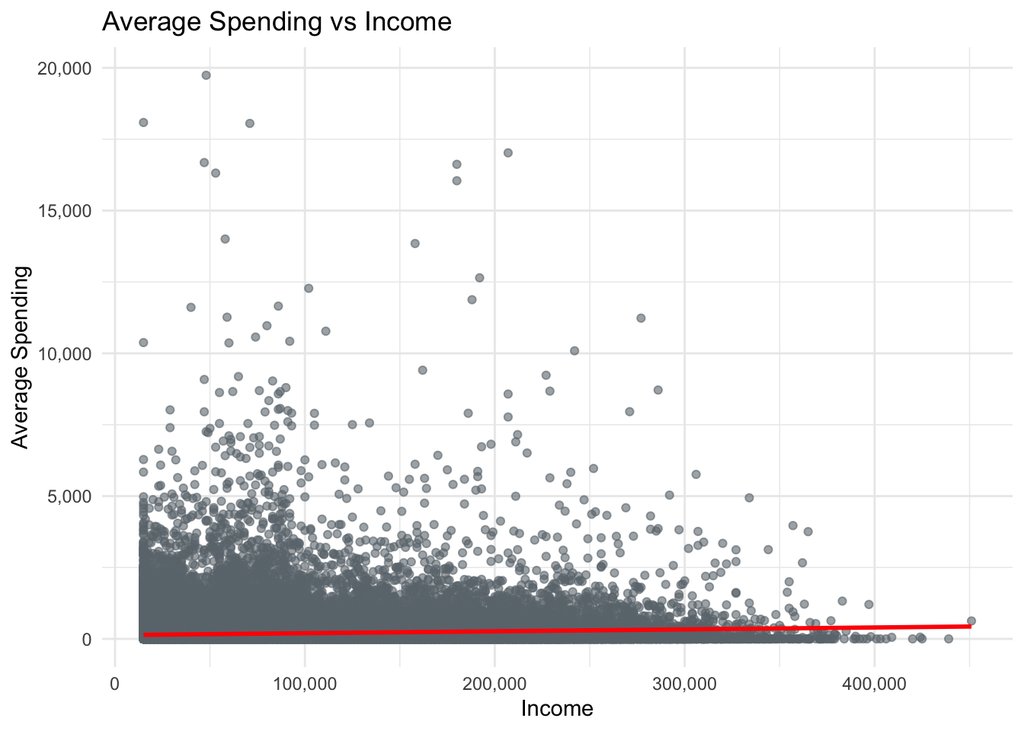

```r
cus_total_spending <- trans_data[,.(total_spending = sum(revenue)), by = customer_id]

customers_data[cus_total_spending,
                      ':=' (total_spending = i.total_spending),
                      on = "customer_id"]

# Replace any missing values (NA) in the 'total_spending' column with 0 in customers_data, indicating no spending in the month for those customers
customers_data[is.na(total_spending), total_spending := 0]

# Fit a linear regression model to predict total spending based on income, age, gender, and region.
lm_cus_avg_spending_income <- lm(total_spending ~ income + age + gender + region,
                                 data = customers_data)
# Extract the coefficient for income from the linear model,
# which indicates the average change in spending per unit increase in income.
income_coef <- as.numeric(coef(lm_cus_avg_spending_income)["income"])

# Calculate the estimated increase in average spending for a $10,000 increase in income, rounding the result to two decimal places.
increase_in_avg_spending <- round(income_coef * 10000, 2)

# Create the plot showing total spending vs income
ggplot(customers_data, aes(x = income, y = total_spending)) +
  geom_point(alpha = 0.6, color = "#6C757D") +  # Scatter plot of total spending
  geom_smooth(method = "lm", se = FALSE, color = "red") +  # Linear regression line
  labs(title = "Average Spending vs Income",
       x = "Income",
       y = "Average Spending") +
  theme_minimal() +
  theme(legend.position = "none")+  # Remove legend if not needed
  scale_y_continuous(labels = label_number(scale = 1, big.mark = ",")) + # Format y-axis
  scale_x_continuous(labels = label_number(scale = 1, big.mark = ","))
```

An increase of $10,000 in income is associated with an increase of $ 6.53 in a customer’s monthly average spending

## 2.5 Number of customers had at least one purchase during the month among customers who viewed at least 1 product

```r
# Calculate the total number of unique customers who viewed products by counting the distinct customer IDs in 'views_data'.
total_num_cus_viewed <- length(unique(views_data$customer_id))

# Calculate the total number of unique customers who made purchases by counting the distinct customer IDs in 'trans_data'.
total_num_purchased <- length(unique(trans_data$customer_id))

# Calculate the percentage of customers who had at least one purchase out of those who viewed at least 1 product, by dividing the number of purchasing customers by the number of viewing customers and multiplying by 100.
pct_cus_viewed_purchased <- total_num_purchased/total_num_cus_viewed*100
```

Total number of customers with a view : 67,243  
Total number of customers who made a purchase: 35,345  
The percentage of customers with a view who made a purchase: 52.56 %

## 2.6 The mean, median, and standard deviation for the number of unique products viewed per customer in different age groups, including 18-34, 35-49, 50-64, and 65+.

```r
# Join 'views_data' with 'customers_data' to add the 'age' column based on matching 'customer_id'.
views_data[customers_data,
           age := i.age,
           on = "customer_id"]

# Create a new column 'age_group' in 'views_data' that categorizes customers into age groups based on the requirements from client's requirement
views_data[, age_group := fifelse(age >= 18 & age <= 34, "18-34",
                                  fifelse(age >= 35 & age <= 49, "35-49",
                                          fifelse(age >= 50 & age <= 64, "50-64", "65+")))]

# Calculate the number of unique products viewed by each customer, grouping by 'customer_id'.
unique_views_per_customer <- views_data[, .(unique_products_viewed = uniqueN(product_id)), by = customer_id]

# Join the 'age_group' information back to the 'unique_views_per_customer' data table, matching on 'customer_id'.
unique_views_per_customer <- unique_views_per_customer[views_data[, .(age_group = unique(age_group)), by = customer_id], on = "customer_id"]

# Calculate summary statistics (mean, median, and standard deviation) for unique products viewed, grouping by 'age_group' and ordering the results by age group.
summary_stats <- unique_views_per_customer[, .(
  mean_views = mean(unique_products_viewed),
  median_views = median(unique_products_viewed),
  sd_views = sd(unique_products_viewed)
), by = age_group][order(age_group)]

# Display the summary statistics in a data table format, rounding numeric values to 2 decimal places and suppressing row names for cleaner output.
datatable(data = summary_stats[, lapply(X = .SD, FUN = "round.numerics", digits = 2)], rownames = FALSE)
```

| age_group | mean_views | median_views | sd_views |
| --- | --- | --- | --- |
| 18-34 | 19.12 | 8 | 36.68 |
| 35-49 | 19.43 | 8 | 38.23 |
| 50-64 | 19.37 | 8 | 35.78 |
| 65+ | 19.03 | 8 | 31.88 |

## 2.7 The increase in a customer’s monthly average spending vs Total Product Views

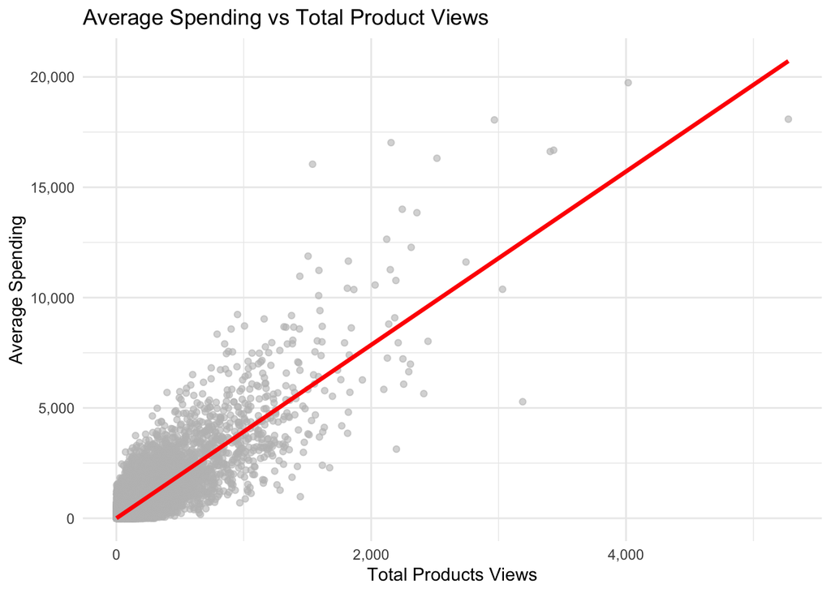

```r
# Calculate the total number of views for each customer by counting the rows in 'views_data' grouped by 'customer_id'.
cus_views <- views_data[, .(total_views = .N), by = customer_id]

# Calculate the total spending for each customer by summing the 'revenue' in 'trans_data', grouped by 'customer_id'.
cus_spending <- trans_data[, .(total_spending = sum(revenue)),
                           by = 'customer_id']

# Join the total spending information to the 'cus_views' data table, adding the 'spending' column.
cus_views[cus_spending,':=' (total_spending = i.total_spending),
                       on = "customer_id"]

# Replace any missing values (NA) in the 'spending' column with 0, indicating no spending for those customers.
cus_views[is.na(total_spending), total_spending := 0]

# Join 'customers_data' to 'cus_views' to add customer demographic variables (age, gender, region).
cus_views[customers_data,
          ':=' (age = i.age,
                gender = i.gender,
                region = i.region),
          on = "customer_id"]

# Fit a linear model to analyze the relationship between spending and the predictors: total views, age, gender, and region.
lm_avg_spending_10_views <- lm(total_spending ~ total_views + age + gender + region, data = cus_views)

# Extract the coefficient for 'total_views' from the fitted linear model.
total_views_coeff <- as.numeric(coef(lm_avg_spending_10_views)["total_views"])

# Calculate the expected increase in average spending for each additional 10 views based on the coefficient, rounding the result to 2 decimal places.
increase_in_avg_spending_views <- round(total_views_coeff * 10, 2)

# Create the plot showing total spending vs total product views
ggplot(cus_views, aes(x = total_views, y = total_spending)) +
  geom_point(alpha = 0.6, color = "grey") +  # Scatter plot with green points
  geom_smooth(method = "lm", se = FALSE, color = "red", size = 1.2) +  # Regression line in orange
  labs(title = "Average Spending vs Total Product Views",
       x = "Total Products Views",
       y = "Average Spending") +
  theme_minimal() +
  theme(legend.position = "none")  +  # Remove legend if not needed
  scale_y_continuous(labels = label_number(scale = 1, big.mark = ",")) + # Format y-axis
  scale_x_continuous(labels = label_number(scale = 1, big.mark = ","))
```

An extra 10 total product views is associated with an increase of $39.27 in a customer’s monthly average spending.

## 2.8 Customer(s) purchased the largest number of coats during the month

```r
# Filter the 'trans_data' for transactions where the 'product_id' is in the list of coat product IDs (coat_prod_id). Calculate the total quantity purchased for each customer by summing the 'quantity' column, grouped by 'customer_id'. Retain only the customers who purchased a total quantity of 10 or more coats. Order the resulting data table by total quantity in descending order.
coat_trans <- trans_data[product_id %in% coat_prod_id,
                   .(total_quantity = sum(quantity)),
                   by = customer_id][total_quantity>=10][order(-total_quantity)]

# Create a datatable to display the results, rounding numeric values to 2 decimal places and removing row names.
datatable(data = coat_trans[, lapply(X = .SD, FUN = "round.numerics", digits = 2)], rownames = FALSE)
```

| customer_id | total_quantity |
| --- | --- |
| tDezWLIaLmm8 | 33 |
| m1pelBQx9EjT | 28 |
| KGTg79nehRi0 | 27 |
| dR8uKDeOk0kI | 26 |
| v3XnIsu0JBTX | 25 |
| hSOlFgCvaFIU | 23 |
| ZAQQpAeDlwpA | 23 |
| PDUcnsOVJS2W | 22 |
| c2Wdpjrktt9c | 22 |
| NmI06HWcog4u | 20 |

[output cut: 126 more lines]